# European COVID-19 Forecast Hub Evaluation Report for epiforecasts-EpiExpert_Rt

2021-11-08

# Latest forecasts

No recent forecasts to show. Click the `Forecast` tab above to view all past forecasts.

## Predictive performance

Skill is shown as weighted interval score.

### Cases

#### 1 week ahead horizon

##### Overall predictive performance

The table shows the skill of the epiforecasts-EpiExpert_Rt model relative to the baseline (`vs. baseline`) and the ensemble model (`vs. ensemble`) for the past 10 weeks in terms of the Weighted Interval Score (`WIS`) and Absolute Error (`AE`). Values less than 1 indicate the model performs better than the model it is being compared with, and values greater than 1 that it performs worse. WIS values are only shown if all 23 quantiles are provided.

| Location | WIS vs. baseline | WIS vs. ensemble | AE vs. baseline | AE vs. ensemble |
| --- | --- | --- | --- | --- |
| Germany | 7.39 | 10.12 | 4.44 | 6.17 |
| United Kingdom | 0.94 | 0.97 | 0.27 | 0.23 |

##### Performance over time

The plots below show the data and forecasts with 50% and 90% predictive intervals and, in the panel to the right of the data plots, forecast skill as measured by the Weighted Interval Score. Lower values indicate better predictive performance.

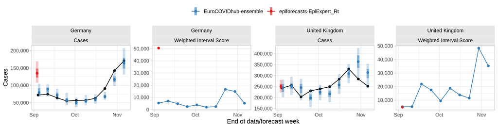

#### 2 weeks ahead horizon

##### Overall predictive performance

The table shows the skill of the epiforecasts-EpiExpert_Rt model relative to the baseline (`vs. baseline`) and the ensemble model (`vs. ensemble`) for the past 10 weeks in terms of the Weighted Interval Score (`WIS`) and Absolute Error (`AE`). Values less than 1 indicate the model performs better than the model it is being compared with, and values greater than 1 that it performs worse. WIS values are only shown if all 23 quantiles are provided.

| Location | WIS vs. baseline | WIS vs. ensemble | AE vs. baseline | AE vs. ensemble |
| --- | --- | --- | --- | --- |
| Germany | 4.12 | 4.16 | 2.56 | 2.59 |
| Poland | 0.81 | 2.53 | 0.05 | 0.13 |
| United Kingdom | 1.22 | 1.04 | 0.45 | 0.34 |

##### Performance over time

The plots below show the data and forecasts with 50% and 90% predictive intervals and, in the panel to the right of the data plots, forecast skill as measured by the Weighted Interval Score. Lower values indicate better predictive performance.

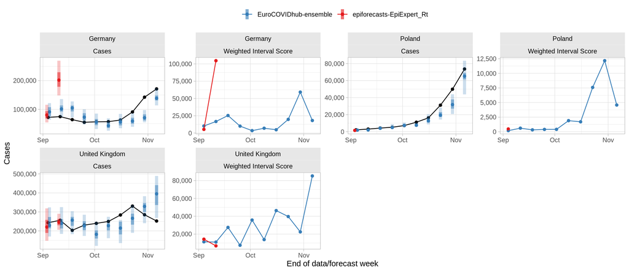

#### 3 weeks ahead horizon

##### Overall predictive performance

The table shows the skill of the epiforecasts-EpiExpert_Rt model relative to the baseline (`vs. baseline`) and the ensemble model (`vs. ensemble`) for the past 10 weeks in terms of the Weighted Interval Score (`WIS`) and Absolute Error (`AE`). Values less than 1 indicate the model performs better than the model it is being compared with, and values greater than 1 that it performs worse. WIS values are only shown if all 23 quantiles are provided.

| Location | WIS vs. baseline | WIS vs. ensemble | AE vs. baseline | AE vs. ensemble |
| --- | --- | --- | --- | --- |
| Germany | 2.81 | 2.32 | 2.14 | 1.73 |
| Poland | 0.94 | 2.24 | 0.1 | 0.18 |
| United Kingdom | 1.16 | 0.89 | 0.69 | 0.54 |

##### Performance over time

The plots below show the data and forecasts with 50% and 90% predictive intervals and, in the panel to the right of the data plots, forecast skill as measured by the Weighted Interval Score. Lower values indicate better predictive performance.

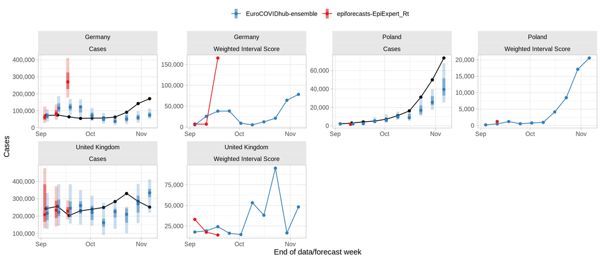

#### 4 weeks ahead horizon

##### Overall predictive performance

The table shows the skill of the epiforecasts-EpiExpert_Rt model relative to the baseline (`vs. baseline`) and the ensemble model (`vs. ensemble`) for the past 10 weeks in terms of the Weighted Interval Score (`WIS`) and Absolute Error (`AE`). Values less than 1 indicate the model performs better than the model it is being compared with, and values greater than 1 that it performs worse. WIS values are only shown if all 23 quantiles are provided.

| Location | WIS vs. baseline | WIS vs. ensemble | AE vs. baseline | AE vs. ensemble |
| --- | --- | --- | --- | --- |
| Germany | 2.46 | 1.63 | 2.15 | 1.41 |
| Poland | 0.81 | 1.65 | 0.09 | 0.14 |
| United Kingdom | 1.16 | 0.76 | 1.22 | 0.84 |

##### Performance over time

The plots below show the data and forecasts with 50% and 90% predictive intervals and, in the panel to the right of the data plots, forecast skill as measured by the Weighted Interval Score. Lower values indicate better predictive performance.

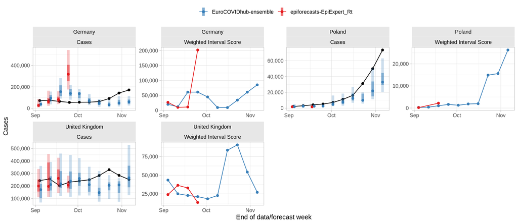

### Deaths

#### 1 week ahead horizon

##### Overall predictive performance

The table shows the skill of the epiforecasts-EpiExpert_Rt model relative to the baseline (`vs. baseline`) and the ensemble model (`vs. ensemble`) for the past 10 weeks in terms of the Weighted Interval Score (`WIS`) and Absolute Error (`AE`). Values less than 1 indicate the model performs better than the model it is being compared with, and values greater than 1 that it performs worse. WIS values are only shown if all 23 quantiles are provided.

| Location | WIS vs. baseline | WIS vs. ensemble | AE vs. baseline | AE vs. ensemble |
| --- | --- | --- | --- | --- |
| Germany | 9.39 | 19.56 | 4.78 | 8.54 |
| United Kingdom | 0.35 | 0.56 | 0.18 | 0.21 |

##### Performance over time

The plots below show the data and forecasts with 50% and 90% predictive intervals and, in the panel to the right of the data plots, forecast skill as measured by the Weighted Interval Score. Lower values indicate better predictive performance.

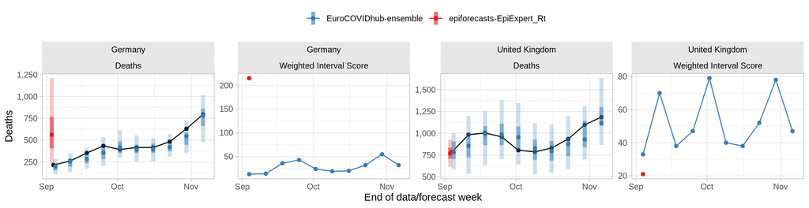

#### 2 weeks ahead horizon

##### Overall predictive performance

The table shows the skill of the epiforecasts-EpiExpert_Rt model relative to the baseline (`vs. baseline`) and the ensemble model (`vs. ensemble`) for the past 10 weeks in terms of the Weighted Interval Score (`WIS`) and Absolute Error (`AE`). Values less than 1 indicate the model performs better than the model it is being compared with, and values greater than 1 that it performs worse. WIS values are only shown if all 23 quantiles are provided.

| Location | WIS vs. baseline | WIS vs. ensemble | AE vs. baseline | AE vs. ensemble |
| --- | --- | --- | --- | --- |
| Germany | 6.72 | 14.61 | 5.12 | 7.76 |
| Poland | 0.16 | 0.67 | 0 |  |
| United Kingdom | 1.1 | 2.2 | 1.3 | 1.78 |

##### Performance over time

The plots below show the data and forecasts with 50% and 90% predictive intervals and, in the panel to the right of the data plots, forecast skill as measured by the Weighted Interval Score. Lower values indicate better predictive performance.

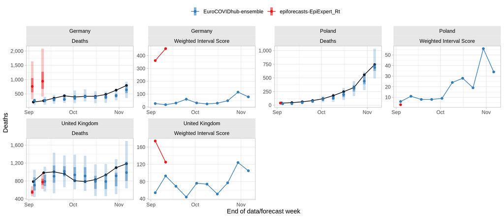

#### 3 weeks ahead horizon

##### Overall predictive performance

The table shows the skill of the epiforecasts-EpiExpert_Rt model relative to the baseline (`vs. baseline`) and the ensemble model (`vs. ensemble`) for the past 10 weeks in terms of the Weighted Interval Score (`WIS`) and Absolute Error (`AE`). Values less than 1 indicate the model performs better than the model it is being compared with, and values greater than 1 that it performs worse. WIS values are only shown if all 23 quantiles are provided.

| Location | WIS vs. baseline | WIS vs. ensemble | AE vs. baseline | AE vs. ensemble |
| --- | --- | --- | --- | --- |
| Germany | 6 | 10.71 | 5.36 | 7.34 |
| Poland | 0.15 | 0.56 | 0.03 | 0.08 |
| United Kingdom | 1.17 | 2.09 | 1.49 | 1.73 |

##### Performance over time

The plots below show the data and forecasts with 50% and 90% predictive intervals and, in the panel to the right of the data plots, forecast skill as measured by the Weighted Interval Score. Lower values indicate better predictive performance.

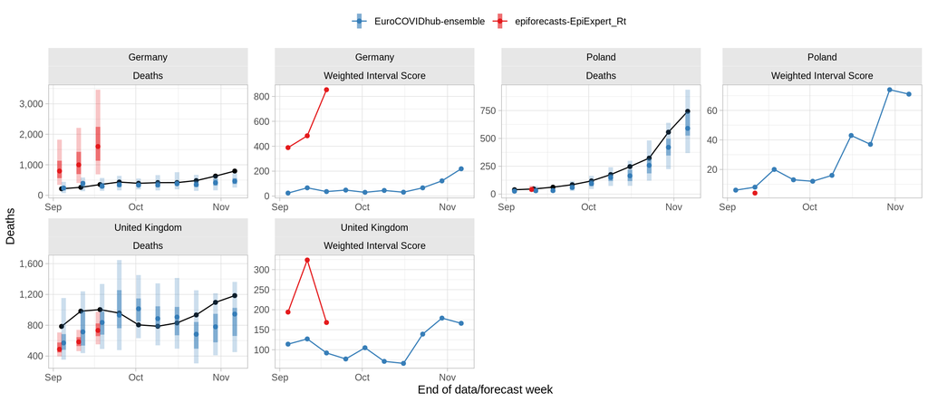

#### 4 weeks ahead horizon

##### Overall predictive performance

The table shows the skill of the epiforecasts-EpiExpert_Rt model relative to the baseline (`vs. baseline`) and the ensemble model (`vs. ensemble`) for the past 10 weeks in terms of the Weighted Interval Score (`WIS`) and Absolute Error (`AE`). Values less than 1 indicate the model performs better than the model it is being compared with, and values greater than 1 that it performs worse. WIS values are only shown if all 23 quantiles are provided.

| Location | WIS vs. baseline | WIS vs. ensemble | AE vs. baseline | AE vs. ensemble |
| --- | --- | --- | --- | --- |
| Germany | 5.43 | 8.48 | 5.22 | 6.78 |
| Poland | 0.35 | 1.09 | 0.11 | 0.26 |
| United Kingdom | 1 | 1.67 | 1.67 | 1.46 |

##### Performance over time

The plots below show the data and forecasts with 50% and 90% predictive intervals and, in the panel to the right of the data plots, forecast skill as measured by the Weighted Interval Score. Lower values indicate better predictive performance.

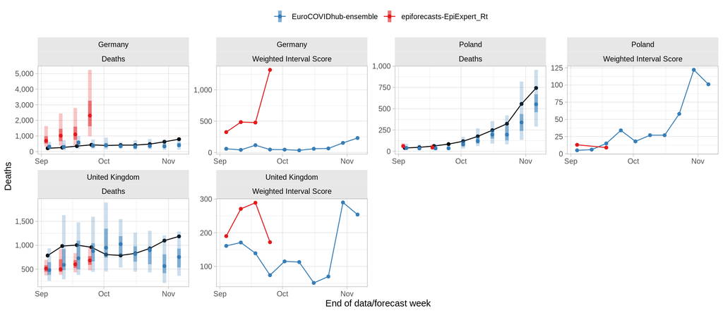

# Forecast calibration

The plots below describe the *calibration* of the model, that is its ability to correctly quantify its uncertainty, across all predicted countries.

#### Overall coverage

Coverage is the proportion of observations that fall within a given prediction interval. Ideally, a forecast model would achieve 50% coverage of 0.50 (i.e., 50% of observations fall within the 50% prediction interval) and 95% coverage of 0.95 (i.e., 95% of observations fall within the 95% prediction interval), incidcated by the dashed horizontal lines below. Values of coverage greater than these nominal values indicate that the forecasts are *underconfident*, i.e. prediction intervals tend to be too wide, whereas values of coverage smaller than these nominal values indicate that the ensemble forecasts are *overconfident*, i.e. prediction intervals tend to be too narrow.

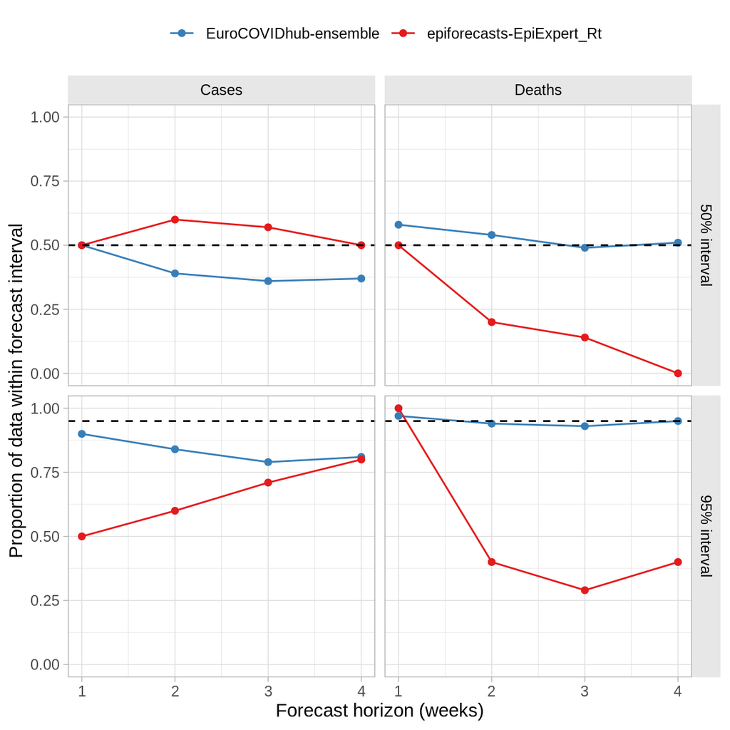

#### PIT histograms

The figures below are *PIT histograms* for the all past forecasts. These show the proportion of true values within each predictive quantile (width: 0.1). If the forecasts were perfectly calibrated, observations would fall evenly across these equally-spaced quantiles, i.e. the histograms would be flat.

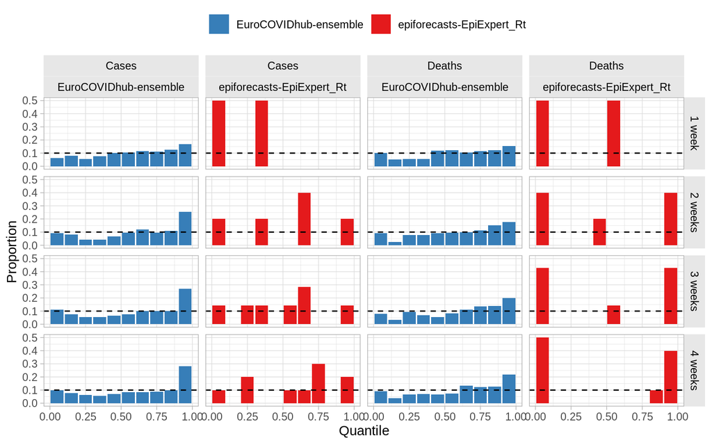